# Assignment 2 - Getting Started with R (4 pts)

Akhil Havaldar (ash2sfp)

Due Date: 11:59pm, Jan 26

**You should submit the html output.**

Note that Reading PASW/SPSS data requires the `read.spss()` function of the *foreign* package (the package should already be installed but you might need to load it using `library(foreign)`, or by checking the box next to the *foreign* package in R Studio). Use `?read.spss` to get some help on the function. Also see the example at the beginning of the *DS3003_introR.R* file.

In order to read the data you need to know where you saved the data set (“inc_real.sav”). Ideally, you save the data in a folder you are going to use. Then you can use the path of the folder to set your working directory (`setwd()`). If you do not know the path of the folder that contains the data, (right)-click on the data file and get the file properties. The file properties contain the path which you can use to set your working directory. Please note that the path can only contain regular slashes (“/”) but no back-slashes (“"). In R studio, you can alternatively set the path via the main menu: Session > Set Working Directory > Choose Directory (then you don’t need the setwd() function to set the directory). Once you set the working directory, everything should work smoothly.

If you like to learn more about Rmarkdown, please see the following websites:

- [R Markdown Cheatsheet](https://www.rstudio.com/resources/cheatsheets/)
- [R Markdown Reference Guide](https://www.rstudio.com/wp-content/uploads/2015/03/rmarkdown-reference.pdf)
- [Introduction to R Markdown by Garrett Grolemund](https://rmarkdown.rstudio.com/articles_intro.html)
- [Get Started Rmarkdown from RStudio](https://rmarkdown.rstudio.com/lesson-1.html)

# 1 Read the csv file “inc_real.sav” (contains real income data) into R and then check the data by doing the following:

- Print the first 6 or 10 rows of the data frame
- Use `dim()` to determine how many rows and columns the data frame has
- Get the variable names (use `names()`),
- Determine the type of variables (numerical, factor, …), i.e., the structure of the data frame (`str()`).

```r
library(foreign)
inc <- read.spss("C:/Users/a8hav/OneDrive/Documents/R/DS-3003/inc_real.sav", to.data.frame=TRUE)
```

```
## re-encoding from CP1252
```

```r
head(inc)   # first 6 rows
```

```
##   age    sex whours                             educat income   hwage edu
## 1  24   male     40 non-tertiary post-secondary degree  18000 112.500  15
## 2  43 female     40               academic high school  14500  90.625  12
## 3  27   male     40                     apprenticeship  18000 112.500  10
## 4  37   male     40                  compulsory school  15700  98.125   9
## 5  50   male     42               academic high school  38000 237.500  12
## 6  50   male     39                     apprenticeship  22000 137.500  10
##   potexp
## 1      3
## 2     25
## 3     11
## 4     22
## 5     32
## 6     34
```

```r
dim(inc)    # how many columns
```

```
## [1] 1271    8
```

```r
nrow(inc)   # how many rows
```

```
## [1] 1271
```

```r
names(inc)  # names of columns
```

```
## [1] "age"    "sex"    "whours" "educat" "income" "hwage"  "edu"    "potexp"
```

```r
str(inc)    # variable types
```

```
## 'data.frame':    1271 obs. of  8 variables:
##  $ age   : num  24 43 27 37 50 50 30 60 45 26 ...
##  $ sex   : Factor w/ 2 levels "male","female": 1 2 1 1 1 1 2 1 1 1 ...
##  $ whours: num  40 40 40 40 42 39 40 39 40 39 ...
##  $ educat: Factor w/ 9 levels "no degree","compulsory school",..: 8 5 3 2 5 3 7 3 3 3 ...
##  $ income: num  18000 14500 18000 15700 38000 22000 5200 12000 15000 13000 ...
##  $ hwage : num  112.5 90.6 112.5 98.1 237.5 ...
##  $ edu   : num  15 12 10 9 12 10 13 10 10 10 ...
##  $ potexp: num  3 25 11 22 32 34 11 44 29 10 ...
##  - attr(*, "variable.labels")= Named chr [1:8] "age" "sex" "working hours" "education (levels)" ...
##   ..- attr(*, "names")= chr [1:8] "age" "sex" "whours" "educat" ...
##  - attr(*, "codepage")= int 1252
```

# 2 Get the summary statistics for the variables in the data frame.

- Use `summary()`. Note that the type of statistic automatically changes with the type of data.

```r
summary(inc)  # summary of data
```

```
##       age            sex          whours
##  Min.   :16.00   male  :839   Min.   :36.00
##  1st Qu.:28.00   female:432   1st Qu.:38.00
##  Median :36.00                Median :40.00
##  Mean   :36.78                Mean   :39.87
##  3rd Qu.:45.00                3rd Qu.:40.00
##  Max.   :64.00                Max.   :80.00
##
##                               educat        income          hwage
##  apprenticeship                  :599   Min.   : 5000   Min.   : 31.25
##  compulsory school               :220   1st Qu.:13000   1st Qu.: 81.25
##  vocational school               :127   Median :15000   Median : 93.75
##  vocational high school          :101   Mean   :16822   Mean   :105.14
##  tertiary education (BA, MA, PhD): 87   3rd Qu.:20000   3rd Qu.:125.00
##  academic high school            : 66   Max.   :80819   Max.   :505.12
##  (Other)                         : 71
##       edu            potexp
##  Min.   : 9.00   Min.   : 0.00
##  1st Qu.:10.00   1st Qu.:11.00
##  Median :10.00   Median :19.00
##  Mean   :10.95   Mean   :19.84
##  3rd Qu.:12.00   3rd Qu.:28.00
##  Max.   :17.00   Max.   :46.00
##
```

# 3 Generate the following sequences using seq() and rep().

- Each sequence should have a length of 20 (i.e., 20 numbers), only the first 12 numbers are shown below.
  - 1 0 1 0 1 0 1 0 1 0 1 0 ….
  - 1 1 0 0 1 1 0 0 1 1 0 0 ….
  - 0 3 6 9 0 3 6 9 0 3 6 9 ….

```r
x <- seq(0,1, by=1)
rep(x, 10)    # first sequence
```

```
##  [1] 0 1 0 1 0 1 0 1 0 1 0 1 0 1 0 1 0 1 0 1
```

```r
y1<- rep(1,2)
y2<- rep(0,2)
y3<- c(y1, y2)
rep(y3, 5)    # second sequence
```

```
##  [1] 1 1 0 0 1 1 0 0 1 1 0 0 1 1 0 0 1 1 0 0
```

```r
z <- seq(0,9,by=3)
rep(z, 5)     # third sequence
```

```
##  [1] 0 3 6 9 0 3 6 9 0 3 6 9 0 3 6 9 0 3 6 9
```

# 4 Plot a histrogram with the income variable from data.

- Use `hist()`.

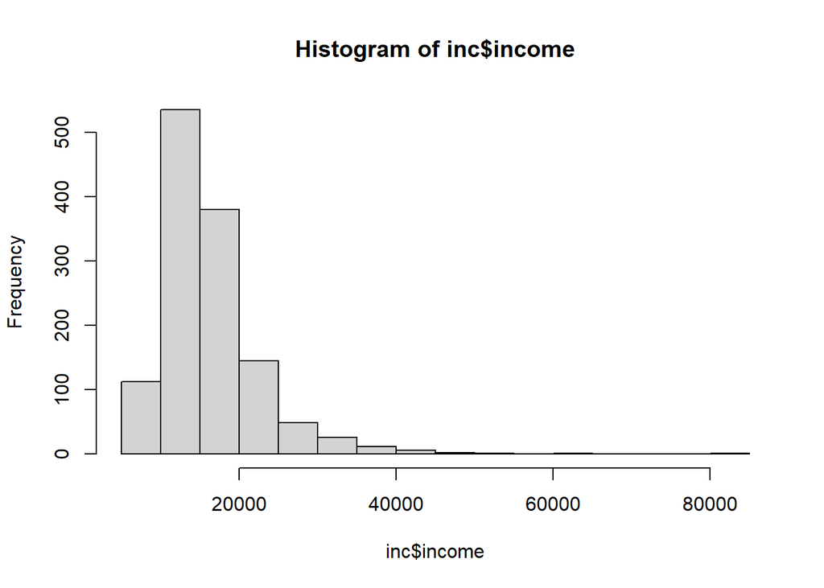

```r
hist(inc$income)  # histogram of income
```